# Estimating Zipf with Clauset et al. method

Molly Lewis

2020-02-07

This markdown estimates the Zipf parameter and min x using the method described in Clauset, Shalizi, and Newman (2009) and implemented in [poweRlaw package](https://github.com/csgillespie/poweRlaw).

Let’s start by reproducing the example from the paper and package documentation. The following example looks at Zipf’s law in Moby Dick.

The data are a vector of word counts sorted from highest to lowest frequency.

```r
# load data
data("moby")
head(moby)
```

```
## [1] 14086  6414  6260  4573  4484  4040
```

Fit a discrete power law

```r
moby_power_law <- displ$new(moby)
```

Estimate xmin

```r
xmin_est <- estimate_xmin(moby_power_law)
xmin_est$xmin
```

```
## [1] 7
```

In this case, xmin_est is 7.

Update power law with estimate xmin_value.

```r
moby_power_law$setXmin(xmin_est)
```

Plot the data - the power law sure *looks* like a good fit to the data.

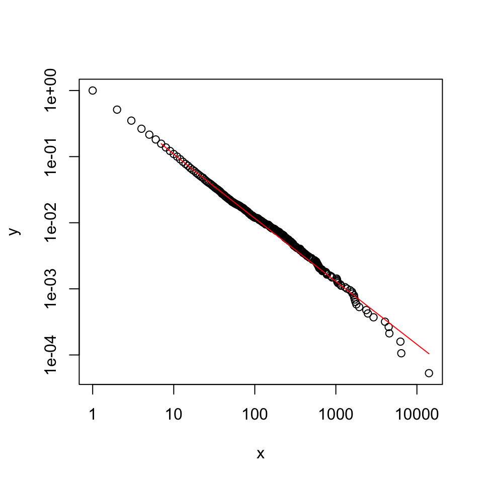

```r
plot(moby_power_law)
lines(moby_power_law, col=2)
```

Let’s do inference - is this actually a power law?

```r
bootstrapped_p_value <- bootstrap_p(moby_power_law)
bootstrapped_p_value$p
```

```
## [1] 0.71
```

Large p-values indicate that the data are likely to have come from the model distribution. In this case, the p-value is 0.71 suggesting the power law is a good fit for the data.

## Our data

Let’s do the same as above except with a community from teh reddit data.

```r
LOCAL_PATH <-  "/Volumes/wilbur_the_great/LANGSCALES_subreddit_sample/misc/all_word_counts.csv"

all_counts <- read_csv(LOCAL_PATH) %>%
  select(subreddit, total_counts)

reddit_test <- all_counts %>%
  filter(subreddit == "morbidquestions") %>%
  arrange(-total_counts) %>%
  pull(total_counts)

head(reddit_test)
```

```
## [1] 133295 108239  91544  89928  70850  66749
```

Again the data are a vector of counts sorted by frequency.

Fit a discrete power law

```r
reddit_power_law <- displ$new(reddit_test)
```

Estimate xmin

```r
xmin_est_reddit <- estimate_xmin(reddit_power_law)
xmin_est_reddit$xmin
```

```
## [1] 446
```

In this case, xmin_est is 446.

Update power law with estimate xmin_value.

```r
reddit_power_law$setXmin(xmin_est_reddit)
```

Plot the data - the power law sure *looks* like a good fit to the data.

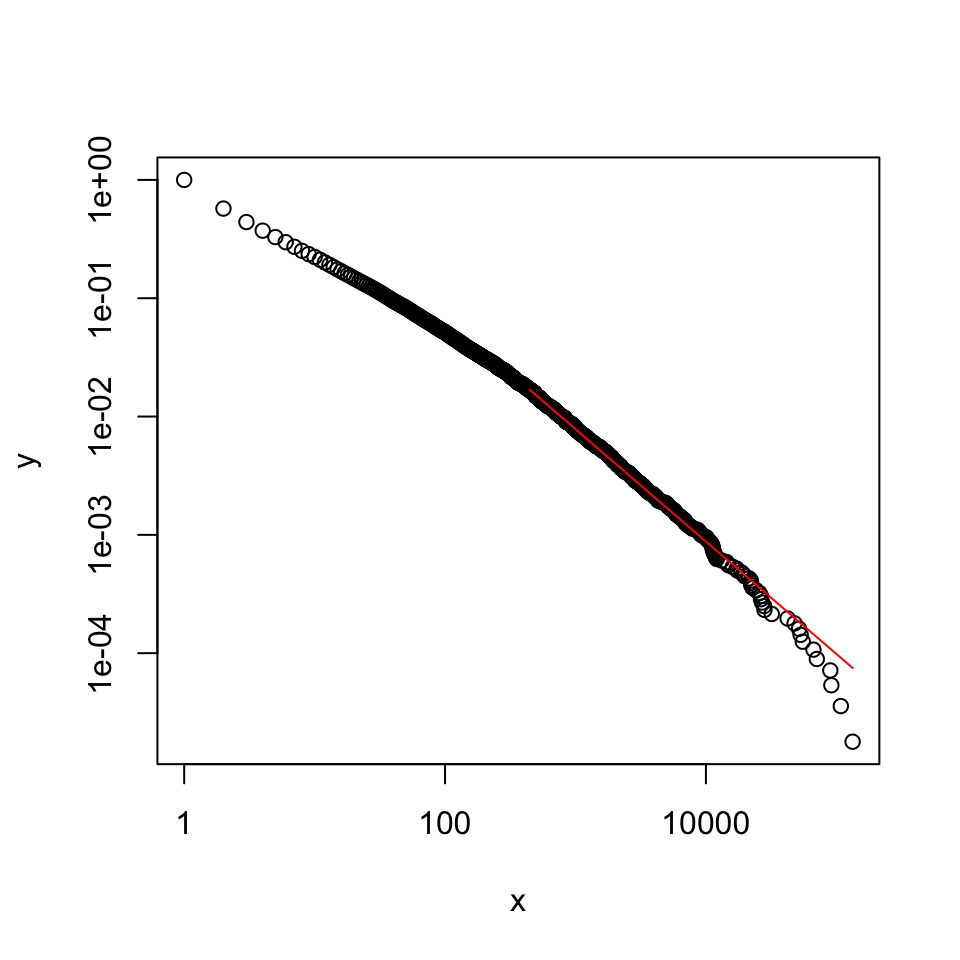

```r
plot(reddit_power_law)
lines(reddit_power_law, col=2)
```

```r
bootstrapped_p_value_reddit <- bootstrap_p(reddit_power_law, threads = 5, xmax = 1000000)
bootstrapped_p_value_reddit$p
```

```
## [1] 0.37
```